# Analyse des posts

```python
# from google.colab import files

# files.upload()
```

```python
import pandas as pd
import numpy as np
import matplotlib.pyplot as plt
# import nltk
# nltk.download()

pd.set_option("display.max_columns", None)

datas = pd.read_csv("P5_02_Posts_final.csv")

datas
```

|  | Id | full_posts | Score | ViewCount | Tags | AnswerCount | FavoriteCount | no_stops_posts |
| --- | --- | --- | --- | --- | --- | --- | --- | --- |
| 0 | 4 | how to convert decimal to double in c# want to... | 745 | 62032.0 | <c#><floating-point><type-conversion><double><... | 12.0 | 59.0 | convert decimal double c# want use track bar c... |
| 1 | 6 | why did the width collapse in the percentage w... | 310 | 22237.0 | <html><css><internet-explorer-7> | 7.0 | 13.0 | width collapse percentage width child element ... |
| 2 | 9 | how do calculate someone is age based on datet... | 2072 | 711798.0 | <c#><.net><datetime> | 68.0 | 483.0 | calculate someone age based datetime types bir... |
| 3 | 11 | calculate relative time in c# given specific d... | 1597 | 185139.0 | <c#><datetime><time><datediff><relative-time-s... | 40.0 | 552.0 | calculate relative time c# given specific date... |
| 4 | 13 | determine user is timezone is there standard w... | 667 | 240907.0 | <html><browser><timezone><user-agent><timezone... | 26.0 | 157.0 | determine user timezone standards way web serv... |
| ... | ... | ... | ... | ... | ... | ... | ... | ... |
| 29096 | 499939 | how to extract the decimal part from floating ... | 60 | 248549.0 | <c><floating-point><decimal><numbers> | 15.0 | 15.0 | extract decimal part floating point numbers ex... |
| 29097 | 499949 | flash loads twice workaround while investigati... | 7 | 3619.0 | <flash><swfobject> | 3.0 | 2.0 | flash loads twice workaround investigating rep... |
| 29098 | 499966 | etag vs header expires ve looked around but ha... | 366 | 136111.0 | <http><caching><etag><expires-header> | 7.0 | 225.0 | etag vs header expires looked around able figu... |
| 29099 | 499967 | how do determine the longest similar portion o... | 9 | 7151.0 | <perl><algorithm><string><similarity> | 7.0 | 4.0 | determine longest similar portion several stri... |
| 29100 | 499995 | how do you validate binary search tree read on... | 63 | 73800.0 | <algorithm><data-structures><binary-search-tree> | 32.0 | 44.0 | validation binary search tree read exercise in... |

29101 rows × 8 columns

```python
# for col in datas.columns:
#     nb_null = datas[col].isnull().sum()
#     # if nb_null > 0:
#         print(f"{col} -- {nb_null}")
```

### Nombre de mots uniques pour "no_stops_posts"

Il faut avant tout utiliser le stemming pour 'unifier' les mots.

```python
# # from nltk.stem.snowball import EnglishStemmer
# from nltk.stem import WordNetLemmatizer

# # stemmer = EnglishStemmer()

# lemmatizer = WordNetLemmatizer()
# words = datas["no_stops_posts"].apply(lambda x: " ".join([lemmatizer.lemmatize(w, "v") for w in x.split()]))

# words
```

```
0        convert decimal double c# want use track bar c...
1        width collapse percentage width child element ...
2        calculate someone age base datetime type birth...
3        calculate relative time c# give specific datet...
4        determine user timezone standards way web serv...
                               ...
29096    extract decimal part float point number extrac...
29097    flash load twice workaround investigate report...
29098    etag vs header expire look around able figure ...
29099    determine longest similar portion several stri...
29100    validation binary search tree read exercise in...
Name: no_stops_posts, Length: 29101, dtype: object
```

```python
# datas["stem_words"] = words
```

Je retire les éventuels mots de 1 lettre.

```python
# def one_letter(words_list):
#     tmp_list = []
#     for word in words_list:
#         if len(word) > 1:
#             tmp_list.append(word)

#     return " ".join(tmp_list)

# datas["stem_words"] = datas["stem_words"].apply(lambda x: one_letter(x.split()))
```

```python
# datas
```

|  | Id | full_posts | Score | ViewCount | Tags | AnswerCount | FavoriteCount | no_stops_posts | stem_words |
| --- | --- | --- | --- | --- | --- | --- | --- | --- | --- |
| 0 | 4 | how to convert decimal to double in c# want to... | 745 | 62032.0 | <c#><floating-point><type-conversion><double><... | 12.0 | 59.0 | convert decimal double c# want use track bar c... | convert decimal double c# want use track bar c... |
| 1 | 6 | why did the width collapse in the percentage w... | 310 | 22237.0 | <html><css><internet-explorer-7> | 7.0 | 13.0 | width collapse percentage width child element ... | width collapse percentage width child element ... |
| 2 | 9 | how do calculate someone is age based on datet... | 2072 | 711798.0 | <c#><.net><datetime> | 68.0 | 483.0 | calculate someone age based datetime types bir... | calculate someone age base datetime type birth... |
| 3 | 11 | calculate relative time in c# given specific d... | 1597 | 185139.0 | <c#><datetime><time><datediff><relative-time-s... | 40.0 | 552.0 | calculate relative time c# given specific date... | calculate relative time c# give specific datet... |
| 4 | 13 | determine user is timezone is there standard w... | 667 | 240907.0 | <html><browser><timezone><user-agent><timezone... | 26.0 | 157.0 | determine user timezone standards way web serv... | determine user timezone standards way web serv... |
| ... | ... | ... | ... | ... | ... | ... | ... | ... | ... |
| 29096 | 499939 | how to extract the decimal part from floating ... | 60 | 248549.0 | <c><floating-point><decimal><numbers> | 15.0 | 15.0 | extract decimal part floating point numbers ex... | extract decimal part float point number extrac... |
| 29097 | 499949 | flash loads twice workaround while investigati... | 7 | 3619.0 | <flash><swfobject> | 3.0 | 2.0 | flash loads twice workaround investigating rep... | flash load twice workaround investigate report... |
| 29098 | 499966 | etag vs header expires ve looked around but ha... | 366 | 136111.0 | <http><caching><etag><expires-header> | 7.0 | 225.0 | etag vs header expires looked around able figu... | etag vs header expire look around able figure ... |
| 29099 | 499967 | how do determine the longest similar portion o... | 9 | 7151.0 | <perl><algorithm><string><similarity> | 7.0 | 4.0 | determine longest similar portion several stri... | determine longest similar portion several stri... |
| 29100 | 499995 | how do you validate binary search tree read on... | 63 | 73800.0 | <algorithm><data-structures><binary-search-tree> | 32.0 | 44.0 | validation binary search tree read exercise in... | validation binary search tree read exercise in... |

29101 rows × 9 columns

```python
# datas.to_csv("P5_04_stem_words.csv", index= False)
```

```python
# datas = datas[["Tags", "stem_words"]]
# datas
```

|  | Tags | stem_words |
| --- | --- | --- |
| 0 | <c#><floating-point><type-conversion><double><... | convert decimal double c# want use track bar c... |
| 1 | <html><css><internet-explorer-7> | width collapse percentage width child element ... |
| 2 | <c#><.net><datetime> | calculate someone age base datetime type birth... |
| 3 | <c#><datetime><time><datediff><relative-time-s... | calculate relative time c# give specific datet... |
| 4 | <html><browser><timezone><user-agent><timezone... | determine user timezone standards way web serv... |
| ... | ... | ... |
| 29096 | <c><floating-point><decimal><numbers> | extract decimal part float point number extrac... |
| 29097 | <flash><swfobject> | flash load twice workaround investigate report... |
| 29098 | <http><caching><etag><expires-header> | etag vs header expire look around able figure ... |
| 29099 | <perl><algorithm><string><similarity> | determine longest similar portion several stri... |
| 29100 | <algorithm><data-structures><binary-search-tree> | validation binary search tree read exercise in... |

29101 rows × 2 columns

```python
# datas.to_csv("P5_04_stem_tags.csv", index= False)
```

```python
datas = pd.read_csv("P5_04_stem_tags.csv")
```

```python
datas
```

|  | Tags | stem_words |
| --- | --- | --- |
| 0 | <c#><floating-point><type-conversion><double><... | convert decimal double c# want use track bar c... |
| 1 | <html><css><internet-explorer-7> | width collapse percentage width child element ... |
| 2 | <c#><.net><datetime> | calculate someone age base datetime type birth... |
| 3 | <c#><datetime><time><datediff><relative-time-s... | calculate relative time c# give specific datet... |
| 4 | <html><browser><timezone><user-agent><timezone... | determine user timezone standards way web serv... |
| ... | ... | ... |
| 29096 | <c><floating-point><decimal><numbers> | extract decimal part float point number extrac... |
| 29097 | <flash><swfobject> | flash load twice workaround investigate report... |
| 29098 | <http><caching><etag><expires-header> | etag vs header expire look around able figure ... |
| 29099 | <perl><algorithm><string><similarity> | determine longest similar portion several stri... |
| 29100 | <algorithm><data-structures><binary-search-tree> | validation binary search tree read exercise in... |

29101 rows × 2 columns

Je prends un échantillon de 10 000 individus aléatoires.

```python
# samples = np.random.choice(len(datas), 10000, replace= False)
# df_samples = datas.iloc[samples, :].reset_index(drop= True)
# df_samples
```

Je crée le bag of words des posts et le retourne dans un dataframe.

```python
from gensim.corpora import Dictionary

docs = datas["stem_words"].apply(lambda x: x.split())

dictionary = Dictionary(docs)
dictionary.filter_extremes(no_below= 20, no_above= 0.5)

print(dictionary)
```

```
Dictionary(4005 unique tokens: ['application', 'bar', 'build', 'c#', 'cannot']...)
```

```python
most_used_word = dictionary.most_common(1)[0]

print(f"Il y a {len(dictionary)} mots uniques")
print(f"Le mot le plus utilisé est {most_used_word[0]} qui apparaît {most_used_word[1]} fois")
```

```
Il y a 4005 mots uniques
Le mot le plus utilisé est file qui apparaît 14557 fois
```

```python
# corpus = [dictionary.doc2bow(doc) for doc in docs]
```

```python
def keep_tokens(posts, words_list):
    post_words_list = []
    for word in posts:
        if word in words_list:
            post_words_list.append(word)

    return " ".join(post_words_list)
```

```python
words_list = set(dictionary.token2id.keys())

datas["imp_words"] = datas["stem_words"].apply(lambda x: keep_tokens(x.split(), words_list))
```

```python
datas
```

|  | Tags | stem_words | imp_words |
| --- | --- | --- | --- |
| 0 | <c#><floating-point><type-conversion><double><... | convert decimal double c# want use track bar c... | convert decimal double c# want track bar chang... |
| 1 | <html><css><internet-explorer-7> | width collapse percentage width child element ... | width collapse percentage width child element ... |
| 2 | <c#><.net><datetime> | calculate someone age base datetime type birth... | calculate someone age base datetime type give ... |
| 3 | <c#><datetime><time><datediff><relative-time-s... | calculate relative time c# give specific datet... | calculate relative time c# give specific datet... |
| 4 | <html><browser><timezone><user-agent><timezone... | determine user timezone standards way web serv... | determine user timezone standards way web serv... |
| ... | ... | ... | ... |
| 29096 | <c><floating-point><decimal><numbers> | extract decimal part float point number extrac... | extract decimal part float point number extrac... |
| 29097 | <flash><swfobject> | flash load twice workaround investigate report... | flash load twice workaround investigate report... |
| 29098 | <http><caching><etag><expires-header> | etag vs header expire look around able figure ... | vs header expire look around able figure expir... |
| 29099 | <perl><algorithm><string><similarity> | determine longest similar portion several stri... | determine similar portion several string per t... |
| 29100 | <algorithm><data-structures><binary-search-tree> | validation binary search tree read exercise in... | validation binary search tree read exercise in... |

29101 rows × 3 columns

```python
# from sklearn.feature_extraction.text import CountVectorizer

# vectorizer = CountVectorizer(token_pattern= r'(?u)[a-zA-Z0-9]+\.?[a-zA-Z0-9]+|\.?[a-zA-Z0-9]+#*-*\+*[a-zA-Z0-9]*', dtype= np.int8)
# # r'(?u)[a-zA-Z0-9]+\.?[a-zA-Z0-9]+|\.?[a-zA-Z0-9]+#*-*\+*[a-zA-Z0-9]*'

# bag_of_words = vectorizer.fit_transform(df_samples["stem_words"])
```

```python
# bag_of_words.shape
```

```python
# bow_dense = bag_of_words.todense()
```

```python
# bow_datas = pd.DataFrame(bow_dense, columns= vectorizer.get_feature_names_out())
```

Je fais la somme des colonnes et transpose le jeu de données pour trouver le mot le plus utiliser et le nombre de mots uniques.

```python
# bow_sum = np.sum(bow_dense, axis= 0)
```

```python
# bow_df = pd.DataFrame(bow_sum, columns= vectorizer.get_feature_names_out())
```

```python
# count_bow_df = bow_df.T.reset_index().rename({"index": "words", 0: "count"}, axis= 1)

# count_bow_df
```

```python
# from sklearn.feature_extraction.text import TfidfVectorizer, TfidfTransformer
# tfidf = TfidfVectorizer()

# tfidf_datas = tfidf.fit_transform(df_samples["stem_words"])


# tfidf_datas.shape
```

```python
# tfidf_dense = pd.DataFrame(tfidf_datas.todense(), columns= tfidf.get_feature_names_out())

# tfidf_dense
```

```python
#prev_count = 0
# summed_tfidf = np.zeros(tfidf_datas.shape[1])

# for i in range(999, tfidf_datas.shape[0] +1000, 1000):
#   arr = tfidf_datas[prev_count: i].toarray()
#   prev_count = i

#   arr = np.sum(arr, axis= 0)
#   summed_tfidf = np.sum(summed_tfidf + arr.reshape(1, -1), axis= 0)
```

```python
# tfidf_df = pd.DataFrame(summed_tfidf, index= vectorizer.get_feature_names_out())

# tfidf_df = tfidf_df.reset_index().rename({"index": "words", 0: "count"}, axis= 1)

# tfidf_df
```

```python
# f_bow = count_bow_df[count_bow_df["words"].isin(tfidf.get_feature_names_out())]
# f_bow
```

```python
# print(f"Il y a {len(f_bow)} mots uniques.")
# tmp_df = f_bow[f_bow["count"] == f_bow["count"].max()].reset_index(drop= True)
# print(f"Le mot le plus utilisé est '{tmp_df.loc[0, 'words']}',\nil apparaît {tmp_df.loc[0, 'count']} fois.")
```

```python
datas.to_csv("P5_04_stem_tags.csv", index= False)
```

Je crée un nuage de mots plus visuel.

```python
datas = pd.read_csv("P5_04_stem_tags.csv")
```

```python
from wordcloud import WordCloud, STOPWORDS

comment_words = ""

for i in range(len(datas)):
    comment_words += datas.loc[i, "imp_words"] + " "

    if (i +1) % 1000 == 0:
        print(f"{i +1}/{len(datas)}")
```

```
1000/29101
2000/29101
3000/29101
4000/29101
5000/29101
6000/29101
7000/29101
8000/29101
9000/29101
10000/29101
11000/29101
12000/29101
13000/29101
14000/29101
15000/29101
16000/29101
17000/29101
18000/29101
19000/29101
20000/29101
21000/29101
22000/29101
23000/29101
24000/29101
25000/29101
26000/29101
27000/29101
28000/29101
29000/29101
```

```python
stopwords = set("")

w_cloud = WordCloud(width= 1600, height= 1600, background_color= "white",
    stopwords= stopwords, min_font_size= 8).generate(comment_words)
```

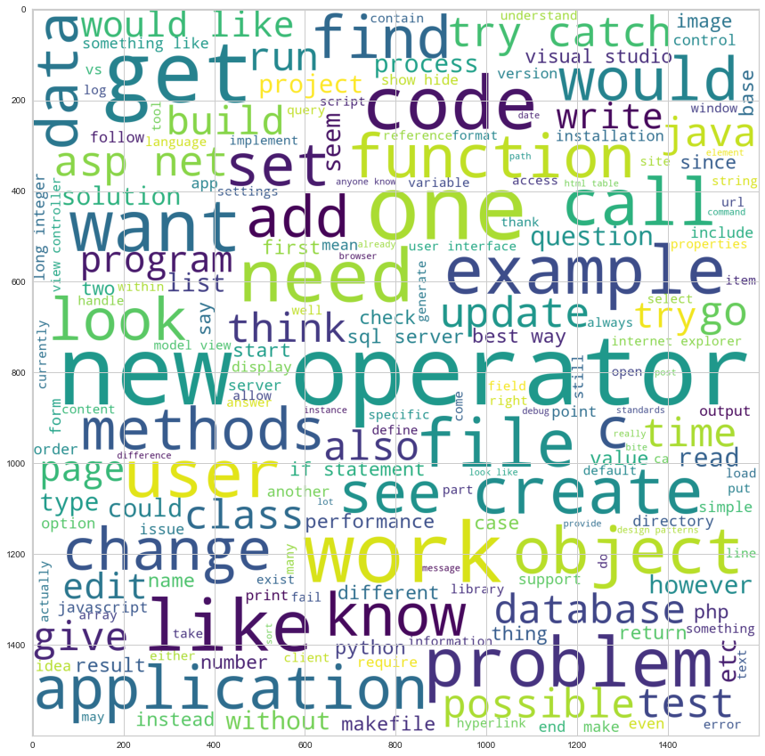

```python
fig = plt.figure(figsize=(15, 15))

plt.imshow(w_cloud)

plt.show()
```

J'effectue un PCA sur le jeu de données pour voir s'il y a des composantes principales significatives.

```python
samples = np.random.choice(len(datas), 10000, replace= False)
df_samples = datas.iloc[samples, :].reset_index(drop= True)
df_samples
```

|  | Tags | stem_words | imp_words |
| --- | --- | --- | --- |
| 0 | <c++><visual-studio-2005><templates><class-des... | resolve error constructor member visual studio... | resolve error constructor member visual studio... |
| 1 | <.net><compact-framework><windows-mobile-5.0> | remove .net compact frameworks windows mobile ... | remove .net compact frameworks windows mobile ... |
| 2 | <asp.net-mvc> | return json handleerror filter aspnet model-vi... | return json filter aspnet model-view-controlle... |
| 3 | <c++><boost><stl><shared-ptr><auto-ptr> | std auto pointers boost share pointers pimpl i... | std auto pointers boost share pointers idioms ... |
| 4 | <sql-server><image><store> | use sql server image store sql server good opt... | sql server image store sql server good option ... |
| ... | ... | ... | ... |
| 9995 | <jquery><asp.net-mvc><json> | post array string asp.net model-view-controlle... | post array string asp.net model-view-controlle... |
| 9996 | <vb.net><debugging><configuration><log4net> | configure log 4net log.isdebugenabled true try... | configure log 4net true try log 4net asp.net a... |
| 9997 | <python><algorithm><sequence> | best way determine sequence another sequence g... | best way determine sequence another sequence s... |
| 9998 | <c++><c><compiler-construction><programming-la... | inadvertent use instead seem instead root many... | instead seem instead root many compiler-constr... |
| 9999 | <wpf><validation> | wpf validation whole form seriously disappoint... | wpf validation whole form seriously wpf valida... |

10000 rows × 3 columns

```python
from sklearn.feature_extraction.text import CountVectorizer

vectorizer = CountVectorizer(token_pattern= r'[\S]+', dtype= np.int8)

bag_of_words = vectorizer.fit_transform(df_samples["imp_words"])

bag_of_words.shape
```

```
(10000, 4005)
```

```python
from sklearn.decomposition import TruncatedSVD, PCA

components = 750

tSVD = TruncatedSVD(n_components= components, random_state= 42)
tSVD.fit(bag_of_words)

tSVD_df = pd.DataFrame(tSVD.transform(bag_of_words))
```

```python
tsvd_expl_ratio_sum = tSVD.explained_variance_ratio_.cumsum()

tsvd_expl_ratio_sum[-1:]
```

```
array([0.8756762])
```

Pas de composante principale significative pour le PCA.

```python
# import seaborn as sns

# t_bow = bow_dense.T

# plt.figure(figsize=(15, 15))

# sns.heatmap(np.corrcoef(t_bow, dtype= np.float16))
```

Visualisation des posts via le TSNE.

```python
from sklearn.manifold import TSNE

tsne = TSNE(init= "random", learning_rate= "auto", random_state= 42)
# tsne.fit(bag_of_words)
```

```python
tsne_df = tsne.fit_transform(bag_of_words)
```

```python
tsne_df = pd.DataFrame(tsne_df, columns= ["PC0", "PC1"])
```

```python
tsne_df
```

|  | PC0 | PC1 |
| --- | --- | --- |
| 0 | 35.172211 | 7.202398 |
| 1 | 11.575737 | -8.706768 |
| 2 | -9.570994 | 8.029333 |
| 3 | 27.192266 | 27.732990 |
| 4 | -14.209103 | -16.251135 |
| ... | ... | ... |
| 9995 | 4.620531 | 24.159292 |
| 9996 | 23.015465 | 34.971081 |
| 9997 | 1.592013 | -27.126091 |
| 9998 | 3.759155 | 0.450222 |
| 9999 | 8.716965 | 8.019756 |

10000 rows × 2 columns

```python
# fig = plt.figure(figsize=(10, 10))
# ax = fig.add_subplot(1, 1, 1)

# plt.plot(distances)

# plt.xlim(6000, len(distances))
# plt.ylim(10, 60)

# ax.set_yticks(np.arange(15, 30, 1), minor= True)
# ax.set_yticks(np.arange(10, 30, 5))
# ax.grid(which= "minor", alpha= 0.3)
# ax.grid(which= "major", alpha= 0.8)

# plt.show()
```

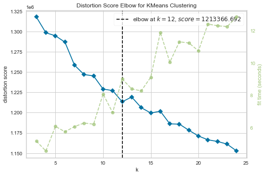

```python
from sklearn.cluster import KMeans
from yellowbrick.cluster import KElbowVisualizer

k_viz = KElbowVisualizer(KMeans(random_state= 42), k=(3, 25))
k_viz.fit(tSVD_df)
k_viz.poof()
```

```python
kmean = KMeans(n_clusters= k_viz.elbow_value_, random_state= 42).fit(tSVD_df)

tsne_df["labels"] = kmean.labels_
```

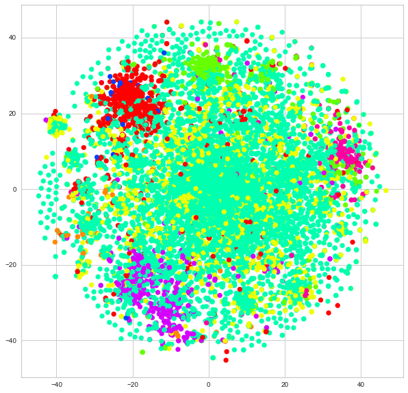

```python
plt.figure(figsize=(10, 10))

plt.scatter(tsne_df.loc[:, "PC0"], tsne_df.loc[:, "PC1"], c= tsne_df.loc[:, "labels"], cmap= "hsv")

plt.show()
```

```python
from sklearn.metrics import silhouette_score

silhouette_score(tSVD_df, tsne_df["labels"])
```

```
0.1379039873460334
```

On ne voit pas de clusters significatifs parmis les posts en se basant sur les mots dans les posts même en réduisant les données à des features significatives via le PCA.

Je peux peut-être trouver un meilleur nombre de clusters avec la méthode du silhouette score.

Suite de la page suivante:

Y a-t-il une ou des composantes principales significatives après un PCA et peut-on voir des clusters clairs pour les tags?

```python
transf_datas_samples = pd.read_csv("P5_06_transf_datas.csv").iloc[samples, :]

transf_datas_samples
```

|  | stem_words | imp_words | Tags |
| --- | --- | --- | --- |
| 20645 | resolve error constructor member visual studio... | resolve error constructor member visual studio... | c++ visual-studio-2005 templates class-des... |
| 5478 | remove .net compact frameworks windows mobile ... | remove .net compact frameworks windows mobile ... | .net compact-framework windows-mobile-5.0 |
| 6117 | return json handleerror filter aspnet model-vi... | return json filter aspnet model-view-controlle... | asp.net-mvc |
| 18509 | std auto pointers boost share pointers pimpl i... | std auto pointers boost share pointers idioms ... | c++ boost stl shared-ptr auto-ptr |
| 19910 | use sql server image store sql server good opt... | sql server image store sql server good option ... | sql-server image store |
| ... | ... | ... | ... |
| 18383 | post array string asp.net model-view-controlle... | post array string asp.net model-view-controlle... | jquery asp.net-mvc json |
| 12789 | configure log 4net log.isdebugenabled true try... | configure log 4net true try log 4net asp.net a... | vb.net debugging configuration log4net |
| 24885 | best way determine sequence another sequence g... | best way determine sequence another sequence s... | python algorithm sequence |
| 23513 | inadvertent use instead seem instead root many... | instead seem instead root many compiler-constr... | c++ c compiler-construction programming-la... |
| 5838 | wpf validation whole form seriously disappoint... | wpf validation whole form seriously wpf valida... | wpf validation |

10000 rows × 3 columns

```python
transf_datas_samples.to_csv("P5_06_samples_datas.csv", index= False)
```

```python
tags_vectorizer = CountVectorizer(token_pattern= r'[\S]+', min_df= 10, dtype= np.int8)

bag_of_tags = tags_vectorizer.fit_transform(transf_datas_samples["Tags"])

tags_df = pd.DataFrame(bag_of_tags.toarray(), columns= tags_vectorizer.get_feature_names_out())

print(tags_df.shape)
tags_df.columns
```

```
(10000, 472)
```

```
Index(['.net', '.net-2.0', '.net-3.5', '2d', '3d', '64-bit', 'actionscript',
       'actionscript-3', 'active-directory', 'activerecord',
       ...
       'xaml', 'xcode', 'xhtml', 'xml', 'xpath', 'xsd', 'xslt', 'xss',
       'zend-framework', 'zip'],
      dtype='object', length=472)
```

```python
components = 200

tPCA = PCA(n_components= components, random_state= 42)
tPCA.fit(tags_df)

tPCA_df = pd.DataFrame(tPCA.transform(tags_df))
```

```python
tsvd_expl_ratio_sum = tPCA.explained_variance_ratio_.cumsum()

tsvd_expl_ratio_sum[-1:]
```

```
array([0.82789196])
```

```python
t_tsne = TSNE(init= "random", learning_rate= "auto", random_state= 42)
```

```python
t_tsne_df = t_tsne.fit_transform(bag_of_tags)
```

```python
t_tsne_df = pd.DataFrame(t_tsne_df, columns= ["PC0", "PC1"])
```

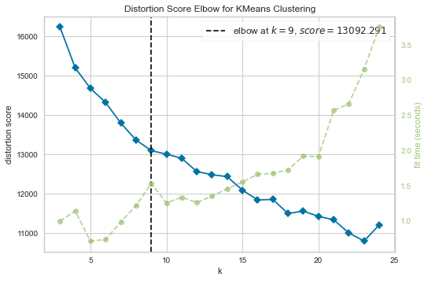

```python
t_k_viz = KElbowVisualizer(KMeans(random_state= 42), k=(3, 25))
t_k_viz.fit(tPCA_df)
t_k_viz.poof()
```

```python
kmean = KMeans(n_clusters= t_k_viz.elbow_value_, random_state= 42).fit(tPCA_df)

t_tsne_df["labels"] = kmean.labels_
```

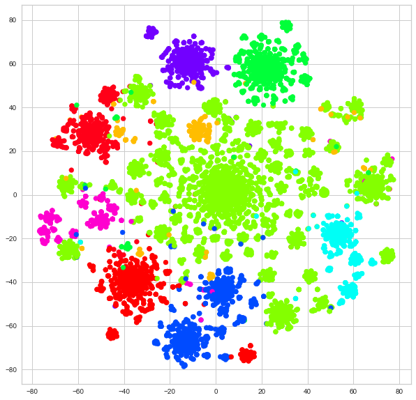

```python
plt.figure(figsize=(10, 10))

plt.scatter(t_tsne_df.loc[:, "PC0"], t_tsne_df.loc[:, "PC1"], c= t_tsne_df.loc[:, "labels"], cmap= "hsv")

plt.show()
```

On peut voir des clusters pour les tags.

Néanmoins, ils semblent assez dispersés voire séparés.

Je vais mesurer un silhouette score pour me faire une idée de la cohérence des clusters.

```python
from sklearn.metrics import silhouette_score

sil_score = silhouette_score(tPCA_df, t_tsne_df["labels"])

sil_score
```

```
0.1540048246795395
```

###### Conclusion

Aucun schéma particulier se dégage des posts.

```python
transf_datas_samples["labels"] = kmean.labels_

transf_datas_samples = transf_datas_samples.sort_values(by= "labels").reset_index(drop= True)

transf_datas_samples
```

|  | stem_words | imp_words | Tags | labels |
| --- | --- | --- | --- | --- |
| 0 | open multi frame tiff imageformat image .net 2... | open multi frame tiff image .net 2.0 path stre... | c# tiff system.drawing | 0 |
| 1 | determine number line within text file easy wa... | determine number line within text file easy wa... | c# input text-files | 0 |
| 2 | add columns datatable bind datagridview update... | add columns datatable bind datagridview update... | c# winforms visual-studio-2008 datagridvie... | 0 |
| 3 | move exist code test drive development recentl... | move exist code test drive development recentl... | c# tdd nunit | 0 |
| 4 | invoke asynchronous call c# web service consum... | invoke asynchronous call c# web service consum... | c# web-services asynchronous function-calls | 0 |
| ... | ... | ... | ... | ... |
| 9995 | function level static variables get allocate i... | function level static variables get allocate i... | c++ variables | 8 |
| 9996 | boost vs ace cross platform performance compar... | boost vs cross platform performance comparison... | c++ performance boost cross-platform ace-... | 8 |
| 9997 | sphere world implementation would best way imp... | world implementation would best way implement ... | c++ data-structures 3d 3d-rendering | 8 |
| 9998 | multiple definition function templates suppose... | multiple definition function templates suppose... | c++ templates linker | 8 |
| 9999 | resolve error constructor member visual studio... | resolve error constructor member visual studio... | c++ visual-studio-2005 templates class-des... | 8 |

10000 rows × 4 columns

```python
transf_datas_samples.to_csv("P5_06_labeled_datas.csv", index= False)
```

```python
ord_tags_vectorizer = CountVectorizer(token_pattern= r'[\S]+', min_df= 10, dtype= np.int8)

bag_of_tags = ord_tags_vectorizer.fit_transform(transf_datas_samples["Tags"])

ord_tags_df = pd.DataFrame(bag_of_tags.toarray(), columns= ord_tags_vectorizer.get_feature_names_out())

print(ord_tags_df.shape)
ord_tags_df.columns
```

```
(10000, 472)
```

```
Index(['.net', '.net-2.0', '.net-3.5', '2d', '3d', '64-bit', 'actionscript',
       'actionscript-3', 'active-directory', 'activerecord',
       ...
       'xaml', 'xcode', 'xhtml', 'xml', 'xpath', 'xsd', 'xslt', 'xss',
       'zend-framework', 'zip'],
      dtype='object', length=472)
```

```python
ord_tags_df_T = ord_tags_df.T
```

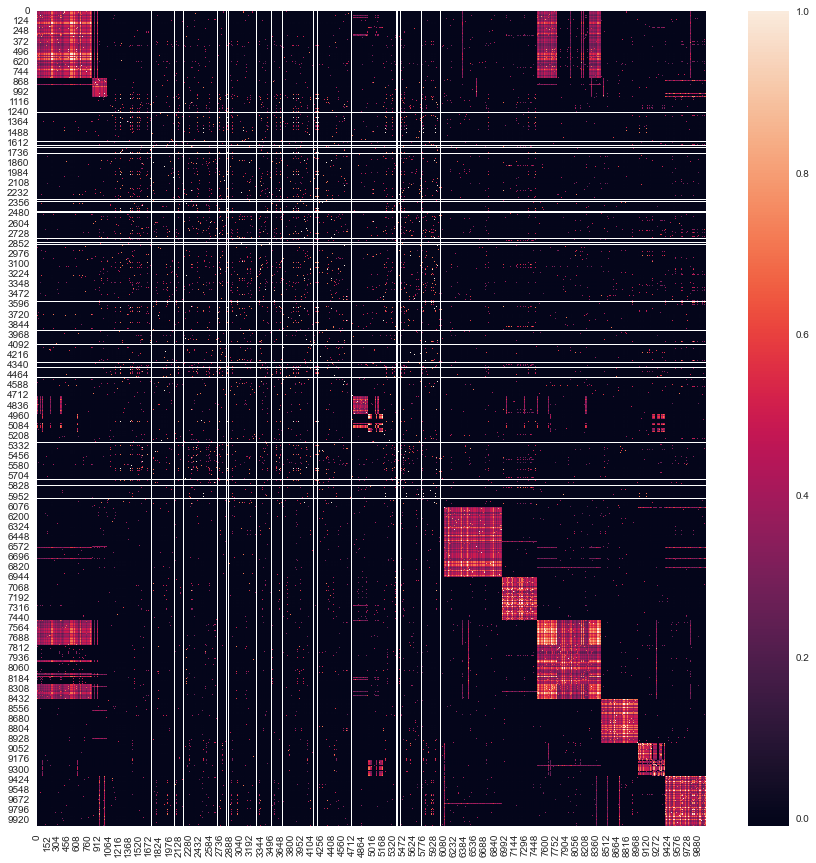

```python
import seaborn as sns

plt.figure(figsize=(15, 15))

sns.heatmap(ord_tags_df_T.corr())
```